# 샘플_인사이트도출

## [자료출처]

- 길벗출판사: 데이터 분석을 위한 전처리와 시각화 with 파이썬
- https://www.gilbut.co.kr/book/view?bookcode=BN003724&keyword=%EC%A0%84%EC%B2%98%EB%A6%AC&collection=GB_BOOK#bookData
- 코드: '연습13-3_예시답안.ipynb'

```python
import numpy as np
import pandas as pd
import matplotlib.pyplot as plt
import seaborn as sns
```

```python
#파일불러오기
df=pd.read_csv('/content/연습문제13-03.csv')
```

```python
#데이터 살펴보기
df.head()
```

|  | school | school_setting | school_type | teaching_method | n_student | student_id | gender | lunch | cs_score |
| --- | --- | --- | --- | --- | --- | --- | --- | --- | --- |
| 0 | ANKYI | Urban | Non-public | Standard | 20 | 2FHT3 | Female | Does not qualify | 72 |
| 1 | ANKYI | Urban | Non-public | Standard | 20 | 3JIVH | Female | Does not qualify | 79 |
| 2 | ANKYI | Urban | Non-public | Standard | 20 | 3XOWE | Male | Does not qualify | 76 |
| 3 | ANKYI | Urban | Non-public | Standard | 20 | 556O0 | Female | Does not qualify | 77 |
| 4 | ANKYI | Urban | Non-public | Standard | 20 | 74LOE | Male | Does not qualify | 76 |

```python
#결측치 확인
df.info()
```

```
<class 'pandas.core.frame.DataFrame'>
RangeIndex: 2133 entries, 0 to 2132
Data columns (total 9 columns):
 #   Column           Non-Null Count  Dtype
---  ------           --------------  -----
 0   school           2133 non-null   object
 1   school_setting   2133 non-null   object
 2   school_type      2133 non-null   object
 3   teaching_method  2133 non-null   object
 4   n_student        2133 non-null   int64
 5   student_id       2133 non-null   object
 6   gender           2133 non-null   object
 7   lunch            2133 non-null   object
 8   cs_score         2133 non-null   int64
dtypes: int64(2), object(7)
memory usage: 150.1+ KB
```

```python
# 학교 위치에 따른 분석
```

```python
df['school_setting'].value_counts()
```

```
Urban       906
Suburban    717
Rural       510
Name: school_setting, dtype: int64
```

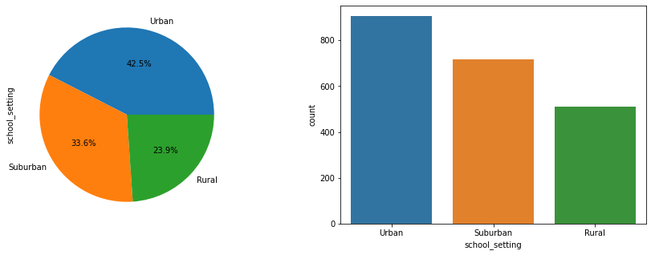

```python
plt.figure(figsize=(15,5))
plt.subplot(1,2,1)
df['school_setting'].value_counts().plot.pie(autopct='%1.1f%%')

plt.subplot(1,2,2)
sns.countplot(df['school_setting'])
```

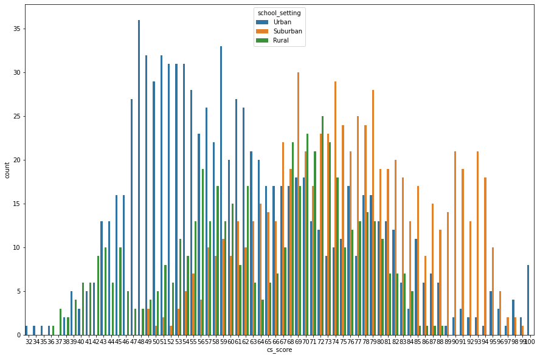

```python
plt.figure(figsize=(15,10))
sns.countplot(x='cs_score', hue='school_setting',data=df)
# 주황색 suburban 지역 학교가 성적이 높음
```

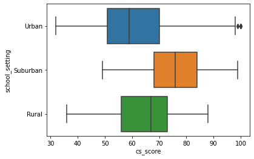

```python
sns.boxplot(x='cs_score',y='school_setting',data=df)

# suburban 지역 학교의 평균 성적이 높음
```

```python
# 학교 유형에 따른 분석
```

```python
df['school_type'].value_counts()
```

```
Public        1582
Non-public     551
Name: school_type, dtype: int64
```

```python
df['school_type'].isnull().sum()
```

[output not shown]

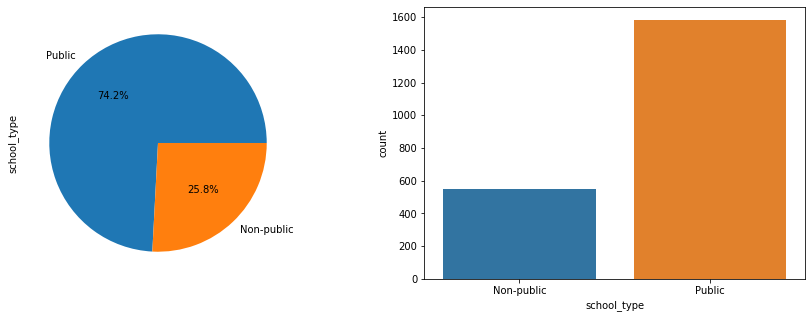

```python
plt.figure(figsize=(15,5))
plt.subplot(1,2,1)
df['school_type'].value_counts().plot.pie(autopct='%1.1f%%')

plt.subplot(1,2,2)
sns.countplot(df['school_type'])
```

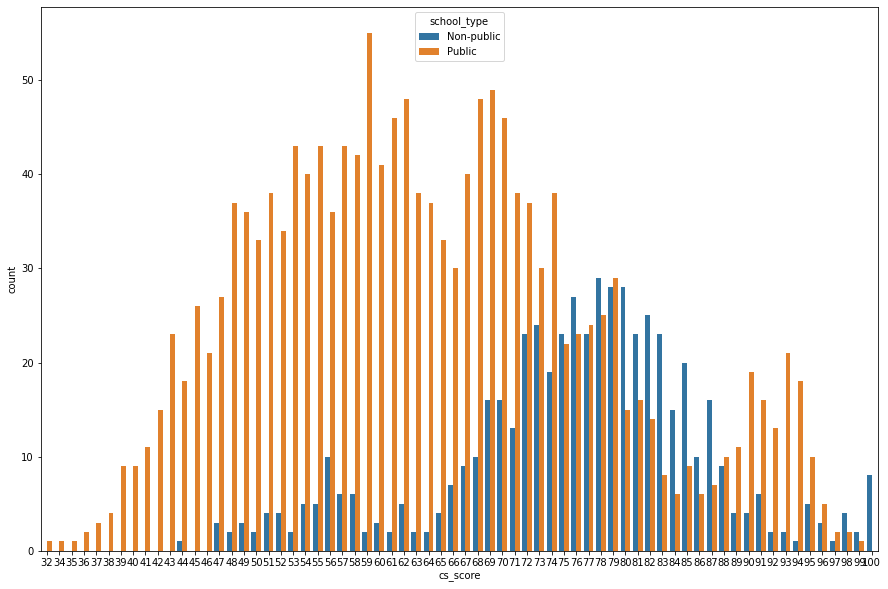

```python
plt.figure(figsize=(15,10))
sns.countplot(x='cs_score', hue='school_type',data=df)
# 공립학교에서 하위권 성적에 많이 분포됨.
```

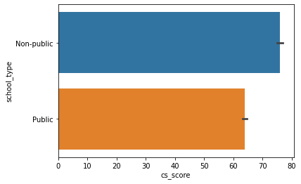

```python
sns.barplot(x='cs_score',y='school_type',data=df)
```

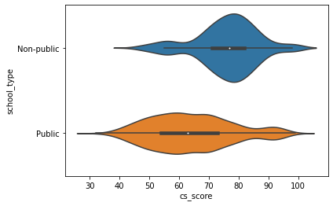

```python
sns.violinplot(x='cs_score',y='school_type',data=df)
# 사립학교 애들의 성적이 높다.
```

```python
# teaching_method에 따른 분석
```

```python
df['teaching_method'].value_counts()
```

```
Standard        1373
Experimental     760
Name: teaching_method, dtype: int64
```

```python
df['teaching_method'].isnull().sum()
```

```
0
```

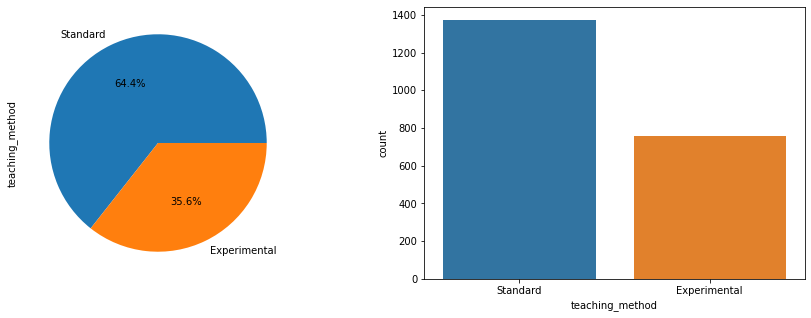

```python
plt.figure(figsize=(15,5))
plt.subplot(1,2,1)
df['teaching_method'].value_counts().plot.pie(autopct='%1.1f%%')

plt.subplot(1,2,2)
sns.countplot(df['teaching_method'])
```

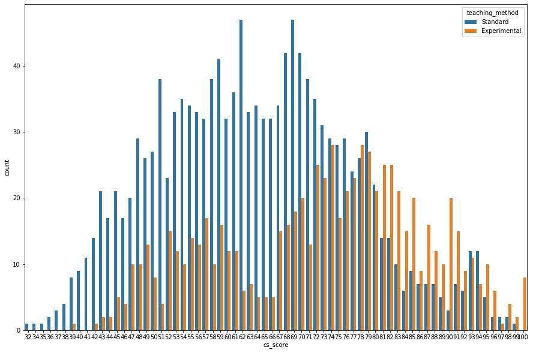

```python
plt.figure(figsize=(15,10))
sns.countplot(x='cs_score', hue='teaching_method',data=df)
# 주황색 실험적인 교육법이 성적이 높음.
```

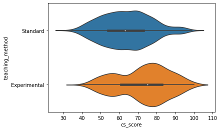

```python
sns.violinplot(x='cs_score',y='teaching_method',data=df)
# experimental한 교육법이 성적이 높다.
```

```python
# 교실 학생수에 따른 분석
```

```python
df['n_student'].unique()
```

```
array([20, 21, 18, 15, 16, 19, 17, 28, 27, 24, 14, 22, 23, 31, 25, 26, 29,
       30])
```

```
22    264
21    231
27    189
28    168
20    160
30    150
24    144
23    138
17    136
19    133
25    125
18     72
16     64
15     45
31     31
29     29
14     28
26     26
Name: n_student, dtype: int64
```

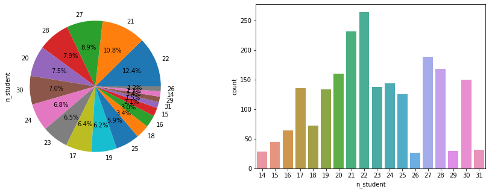

```python
plt.figure(figsize=(15,5))
plt.subplot(1,2,1)
df['n_student'].value_counts().plot.pie(autopct='%1.1f%%')
plt.subplot(1,2,2)
sns.countplot(df['n_student'])

df['n_student'].value_counts()
```

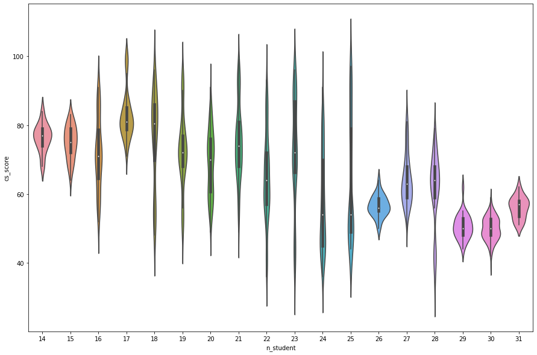

```python
plt.figure(figsize=(15,10))
sns.violinplot(x='n_student',y='cs_score',data=df)
```

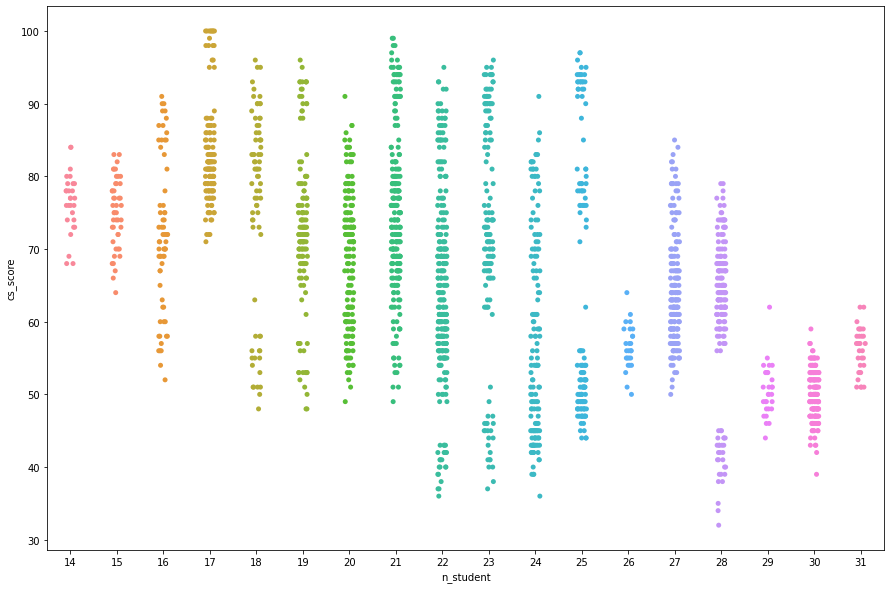

```python
plt.figure(figsize=(15,10))
sns.stripplot(x='n_student',y='cs_score',data=df)

# 한 교실에 학생 수가 많으면 성적이 낮음
```

```python
# 성별에 따른 분석
```

```
Male      1077
Female    1056
Name: gender, dtype: int64
```

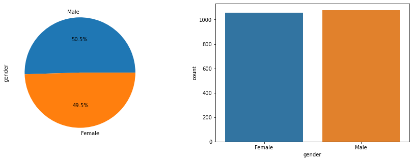

```python
plt.figure(figsize=(15,5))
plt.subplot(1,2,1)
df['gender'].value_counts().plot.pie(autopct='%1.1f%%')
plt.subplot(1,2,2)
sns.countplot(df['gender'])
df['gender'].value_counts()
```

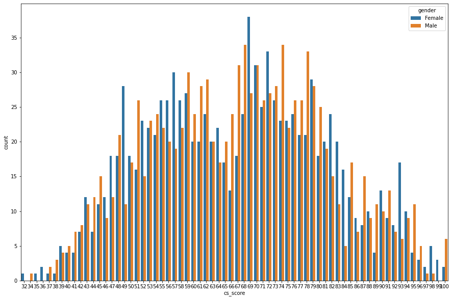

```python
plt.figure(figsize=(15,10))
sns.countplot(x='cs_score', hue='gender',data=df)
```

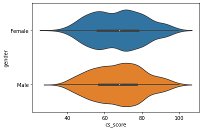

```python
sns.violinplot(x='cs_score',y='gender',data=df)
# 성별에 따른 성적 차이는 나타나지 않음.
```

```python
# 점심제공에 따른 분석
```

```
Does not qualify                    1215
Qualifies for reduced/free lunch     918
Name: lunch, dtype: int64
```

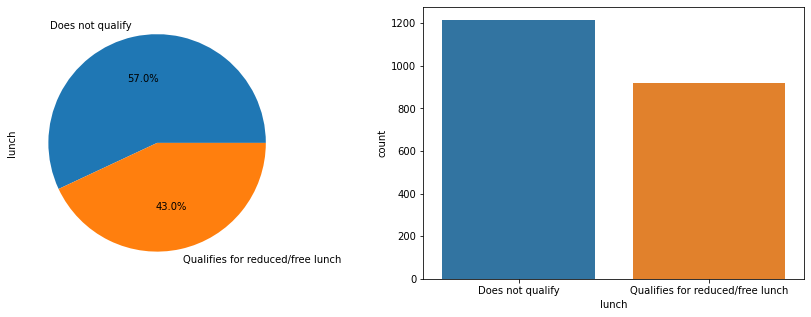

```python
plt.figure(figsize=(15,5))
plt.subplot(1,2,1)
df['lunch'].value_counts().plot.pie(autopct='%1.1f%%')
plt.subplot(1,2,2)
sns.countplot(df['lunch'])
df['lunch'].value_counts()
```

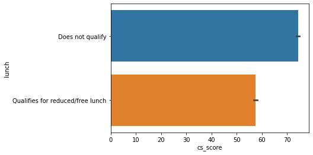

```python
sns.barplot(x='cs_score',y='lunch',data=df)
#점심제공 받는 학습자의 평균 성적이 낮음
```

```python
# 다변량 데이터도 분석해보자.
# school_type와 teaching_method의 관계와 cs_score에 미치는 영향
```

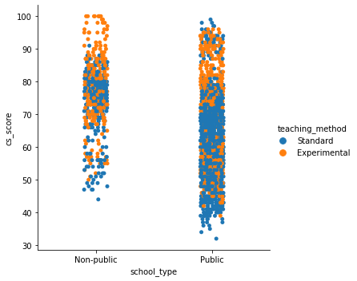

```python
sns.catplot(x='school_type',y='cs_score',hue='teaching_method',data=df)

#사립학교가 experimental 많이 하고,
#공립 중에서 experimental 하는 곳도 몇 있음
#experimental을 적용하는 학교는 성적이 높음
```

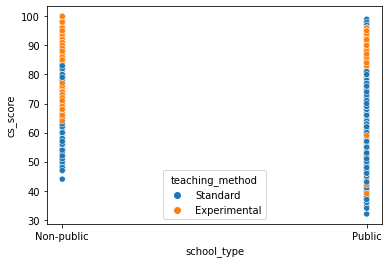

```python
sns.scatterplot(x='school_type',y='cs_score',hue='teaching_method',data=df)
```

```python
# 다변량 데이터 분석2
# school_type와 n_student의 관계와 cs_score에 미치는 영향
```

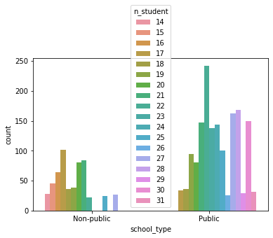

```python
sns.countplot(x='school_type',hue='n_student',data=df)
```

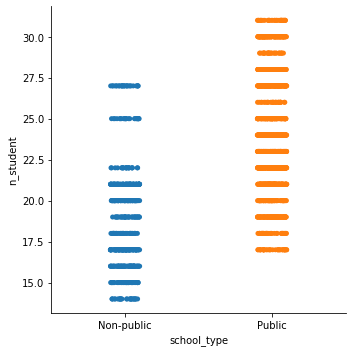

```python
sns.catplot(x='school_type',y='n_student',data=df)

# 공립학교일수록 학급당 학생수 높고, 사립학교일수록 학급당 학생수 낮음
```

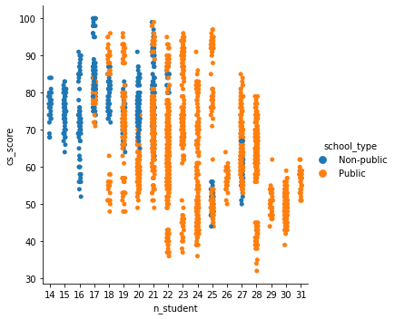

```python
sns.catplot(x='n_student',y='cs_score',hue='school_type',data=df)

# 사립학교일수록 학급당 학생수 적어지고, 이럴경우 성적 높음
# 공립학교일수록 학급당 학생수 많아지고, 이럴 경우 성적이 낮음
```

[답안 예시]

1. 시험성적이 높은 그룹의 특징은 무엇인가?
- suburban 지역일수록 성적이 높음
- non-public 학교일수록 성적이 높음
- experimental 교육법일수록 성적이 높음
- 학급 당 학생 수가 낮을수록 성적이 높음
2. 중요한 특성(속성)은 무엇인가?
- school_setting (학교 위치)
- school_type (학교 유형)
- teaching_method (교육 방법)
- n_student (학급 당 학생 수)
- lunch (점심 제공 여부)
3. 위 데이터 특성을 분석항으로 알 수 있는것은 무엇인가?
- suburban 지역의 학생일수록 성적이 높은 경향이 있음
- 사립학교일수록 성적이 높은 경향이 있다. -실험적인 교육법을 쓸수록 성적이 높은 경향이 있고, 학급당 학생수가 낮을수록 성적이 높은 경향이 있다.
- 점심 제공받는 학생일수록 성적이 낮은 경향이 있다.
- 사립학교일수록 실험적인 교육법을 많이 쓰며, 성적이 더 높음
- 또한, 학교 유형과 학급당 학생수와 성적 간의 연관성을 조사해본 결과, 사립학교 일수록 학급당 학생수가 적고 성적도 더 높게 나온다는 것이 파악되었다.
4. 높은 성적을 받기 위해 어떠한 아이디어를 제시할 수 있는가?
1. 실험적인 교육법을 쓸수록 성적이 높아짐 => 토론 수업의 확대, 정형화된 교과서 학습에서 벗어나 창의 체험 활동 및 실험 활동 확대, 플립 러닝과 같은 교육법을 실제 수업에 적용할 수 있는 교육 퐁토 조성
2. 학급당 학생수가 낮을 수록 성적이 높아짐 => 학급당 학생 수를 일정 수로 제한을 두는 정책을 이 필요함
5. 이 외에 추가적으로 필요한 데이터가 있는가?
- 소득분위에 따른 정보가 필요함. 저소득층 학생이 성적이 낮게 나오는 경향성이 파악되면, 저소득층 아이들의 성적 향상을 위한 학습 지원 방법을 제시할 수 있을 것이다.